# GSoC 2019 sgdnet project tests

##### Qincheng Lu qinchenglu@gmail.com, 4/8/2019

## Easy

This part is a comparison between **sgdnet** and **glmnet**, in terms of the time and loss for gaussian, logistic and multinomial families. I use the loss function with elastic-net penalty as follows, where $\lambda = 1$ is the parameter for lasso penalty ([for R code](https://github.com/wzzlcss/sgdtest/blob/master/sgdtest/R/lossfunction.R)).

- Gaussian: $\frac{1}{2}\left \| \boldsymbol{XW} -\boldsymbol{y} \right \| ^{2} + \lambda \alpha \left \| \boldsymbol{W} \right \|_{1} + \lambda (1- \alpha) \left \| \boldsymbol{W} \right \|_{2}$.
- Logistic regression:
  - Loss = $\frac{1}{n}\sum_{i=1}^{n} \rho_{W}(\boldsymbol{X_{i}},{y{i}}) + \lambda \alpha \left \| \boldsymbol{W} \right \|_{1} + \lambda (1- \alpha) \left \| \boldsymbol{W} \right \|_{2}$;
  - $\rho_{W}(\boldsymbol{X},{y}) = -\boldsymbol{y}(\sum_{j=1}^{p+1} \boldsymbol{w}_{j}\boldsymbol{x}^{(j)}) + log(1+ exp(\sum_{j=1}^{p+1} \boldsymbol{w}_{j}\boldsymbol{x}^{(j)}))$.
- Multinomial families:
  - Loss = $\frac{1}{n}\sum_{i=1}^{n} \rho_{W}(\boldsymbol{X_{i}},{y{i}}) + \lambda \alpha \sum_{k=1}^{c} \left \| \boldsymbol{W^{(k)}} \right \|_{1} + \lambda (1-\alpha) \sum_{k=1}^{c} \left \| \boldsymbol{W^{(k)}} \right \|_{2}$;
  - $\rho_{W}(\boldsymbol{X},{y}) = -(\sum_{j=1}^{p+1} \sum_{k=1}^{c} \boldsymbol{y_{l}} \, \boldsymbol{w}^{(k)}_{j} \boldsymbol{x}^{(j)}) + log(1+ exp(\sum_{j=1}^{p+1}\sum_{k=1}^{c} \boldsymbol{w}^{(k)}_{j} \boldsymbol{x}^{(j)}))$, where $\boldsymbol{y}_{l} = I(\boldsymbol{y}=l), l = 1,...,c$.

Test is based on dataset **abalone** and **cadata**, which are from [LIBSVM](https://www.csie.ntu.edu.tw/~cjlin/libsvmtools/datasets/). **abalone** contains 4177 observations and 8 features. **cadata** contains 20,640 observations and 8 features. The response variables for both are continuous. For logistic and multinomial models, the response variable is transformed into categorical data according to median and $1^{st}$, $2^{nd}$ and $3^{rd}$ quantiles. Here I take a step size $\gamma = 1/n.obs$. In Figure 1 and 2, loss objectives are collected at a sequence of runtime, when two function adopts a same stopping criteria. The first row of each figure are results with lasso penalty and the second with ridge penalty.([My R code](https://github.com/wzzlcss/sgdtest/blob/master/sgdtest/R/Benchmark.R))

##### (1) Benchmark results on abalone dataset

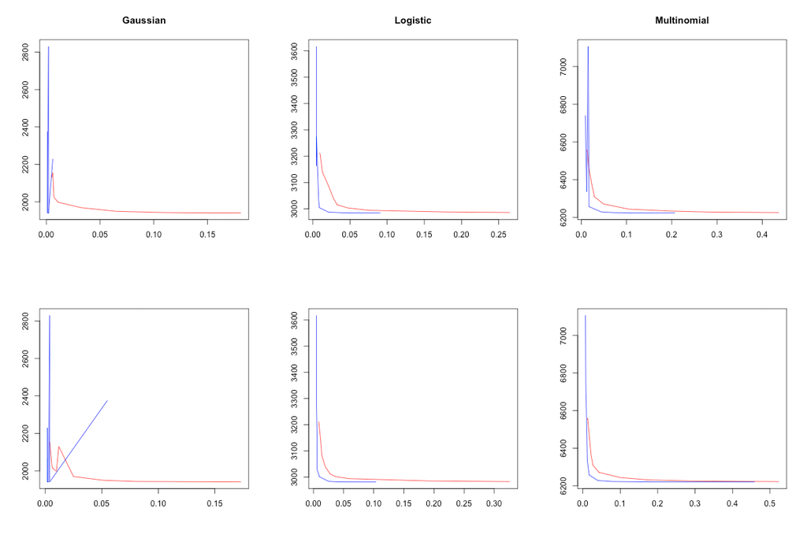

Benchmark on abalone dataset

##### (2) Benchmark results on cadata dataset

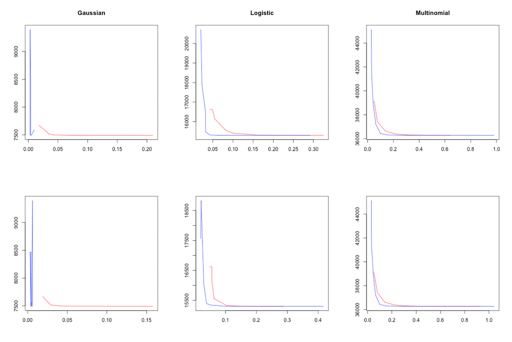

Benchmark on cadata dataset

## Median

This part use **RcppEigen** to write a class that defines the lasso ($\mathcal{l}_1$) penalty. Here we only have lasso terms and set $\alpha=1$, and $\lambda = \frac{1}{n}$ for regularization strength, and $\gamma > 0$ is the step size. The proximal mapping of a convex function $h$ is defined as

$$prox_{h}(x) = arg \underset{u}{min} \left ( h(u) + \frac{1}{2} \left \| u-x \right \|^{2}_{2} \right )$$

For $h(\boldsymbol{\omega})$ = $\left \| \boldsymbol{\omega} \right \| _{1}$ as our lasso penalty, the proximal mapping of $h$ is denoted as $prox_{h}(\boldsymbol{\omega})$, which is specified as `soft - threshould’ for lasso. For each entry of $\omega$

$$prox_{h}(\boldsymbol{\omega_{i}}) =
\left\{\begin{matrix}
\omega_{i} - 1 & \omega_{i} \geq 1 \\
0 & \left \|\omega_{i} \right \|_1 \leq 1\\
\omega_{i} + 1 & \omega_{i} \leq -1
\end{matrix}\right.$$

In iteration $k+1$, we first conduct the gradient descent step
$$\boldsymbol{\omega}^{\frac{1}{2}+k} \leftarrow \boldsymbol{\omega}^{k} - \gamma \nabla f(\boldsymbol{\omega}^{k}) \, \, (*)$$
Then update $\boldsymbol{\omega}^{k+1} = prox_{\gamma h}(\boldsymbol{\omega}^{\frac{1}{2}+k}) = arg \underset{u}{min} \left \{ \lambda \alpha \left \|u \right \|_{1} + \frac{1}{2} \left \| u- \boldsymbol{\omega}^{\frac{1}{2}+k} \right \|^{2}_{2} \right \}$ following the definition. Then the updated $\boldsymbol{\omega}^{k+1}$ has each entry equals to $\frac{\omega_{j}}{\left \|\omega_{j}\right \|_1} max \{0, \left \|\omega_{j} - \alpha \lambda \right \|_1 \}$, where $\omega_{j}$ is the corresponding entry in $\boldsymbol{\omega}^{\frac{1}{2}+k}$. The loss is straightforward to be evaluated as $\lambda \alpha \left \| \boldsymbol{\omega^{k}} \right \| _{1}$.

In l1.h, we define the class.

```r
// [[Rcpp::depends(RcppEigen)]]
#include <RcppEigen.h>
#include <Rcpp.h>
using namespace Rcpp;
using namespace RcppEigen;
#ifndef L1_H
#define L1_H
class l1{
public:
  l1(Eigen::MatrixXd W_, double alpha_, double rate_);
  Eigen::MatrixXd prox();
  double loss();

private:
  Eigen::MatrixXd W;
  double alpha;
  double rate;
};
#endif
```

And the corresponding functions **prox()** and **loss()** are defined in SGD.cpp.

```r
l1::l1(Eigen::MatrixXd W_, double alpha_, double rate_):
  W(W_), alpha(alpha_), rate(rate_){}
Eigen::MatrixXd l1::prox(){
  int n = W.rows();
  Eigen::MatrixXd Wnew = W;
  double w = 0;
  double tmp = 0.0;
  for (int i=0; i<n; i++){
    w = W(i,0)/std::abs(W(i,0));
    tmp = W(i,0) - alpha*rate;
    if (tmp < 0){Wnew(i,0)=0;}
    else {Wnew(i,0) = tmp*w;}
  }
  return(Wnew);
}

double l1::loss(){
  int n = W.rows();
  double loss = 0.0;
  for (int i=0; i<n; i++){loss+=std::abs(W(i,0));}
  loss = loss * alpha *rate;
  return(loss);
}
```

For this question, we do not need to consider the step size $\gamma$. An object is created using **lasso** $\leftarrow$ **new**($\boldsymbol{\mathcal{l}_1}$, $\boldsymbol{W}$, $\boldsymbol{lambda}$, $\boldsymbol{\alpha}$), and its loss and proximal vector is returned by **lasso$loss()** and **lasso$prox()**.

```r
library(sgdtest)
W <- as.matrix(c(2.9579215,0.9848356))
lasso <- new(l1, W, 0.01, 1)
lasso$prox() # proximal operator(soft thresholing)
```

```
##           [,1]
## [1,] 2.9479215
## [2,] 0.9748356
```

```r
lasso$loss() # evaluate the loss
```

```
## [1] 0.03942757
```

## Hard

In the regular stochastic gradient descent algorithm, the equation $(*)$ becomes:

$$\boldsymbol{\omega}^{\frac{1}{2}+k} \leftarrow \boldsymbol{\omega}^{k} - \gamma \nabla f_{i}(\boldsymbol{\omega}^{k}), \, i \leftarrow U(1, n)$$
.

My function **SGD**($\boldsymbol{X}$, $\boldsymbol{y}$, **iter**, $\boldsymbol{\lambda}$, $\boldsymbol{\alpha}$, $\boldsymbol{\gamma}$) is implemented in SGD.cpp of **sgdtest**. The parameter $\boldsymbol{X}$ is a matrix including intercept terms, and $\boldsymbol{y}$ is a one-column matrix. The stopping occurs when the algorithm is iterated up to number **iter**, with step length equals to $\gamma$. And by setting $\alpha=1$, the function is regularized by lasso penalty with regularization strength $\lambda$. The following code is the algorithm part of my package **sgdtest**.

```r
// [[Rcpp::export]]
Eigen::MatrixXd SGD(const Eigen::MatrixXd & X,
                     const Eigen::MatrixXd & y,
                     const int & iter,
                     const double & rate,
                     const double & alpha,
                     const double & size)
{
  /**Intialization*/
  int n = y.size();
  int m = X.cols();
  int idx = 0;
  Eigen::MatrixXd error(1,1);
  Eigen::MatrixXd W(m,1);
  Eigen::MatrixXd Gradient(m,1);
  error.fill(0.0);
  W.fill(0.0);
  Gradient.fill(0.0);

  /**Iteration*/
  for(int i=0; i<iter; i++){
    /**Generate random number*/
    Rcpp::IntegerVector pool = Rcpp::seq(0, n-1);
    std::random_shuffle(pool.begin(), pool.end());
    idx = pool[0];

    /**Gradient Descent*/
    error = X.row(idx)*W - y.row(idx);
    Gradient = X.row(idx).transpose()*error;
    W = W - Gradient * size;

    /**lasso penality*/
    if (alpha != 0.0){
      l1 s = l1(W, alpha, rate);
      W = s.prox();
    }
  }
  return W;
}
```

A simple case shows that my package actually works. I simulate $1000$ sample $\boldsymbol{X} \sim \boldsymbol{U}(-5, 5)$ and set $\boldsymbol{y} = \boldsymbol{X} + \boldsymbol{\epsilon} + 3$ where $\boldsymbol{\epsilon} \sim \boldsymbol{N}(0,1)$. For lasso penalty, I use set parameters as **SGD**($\boldsymbol{X}$,$\boldsymbol{y}$,600, 0.001, 1, 0.005) And this is a comparison among the fitted coefficients from **sgdtest** with and without lasso penalty, the **lm( )** function which is unbiased, and the results from **sgdnet** and **glmnet** with lasso penalty.

```r
set.seed(0)
x <- runif(1000, -5, 5)
y <- x + rnorm(1000) + 3
X <- matrix(cbind(1, matrix(x)), nrow = 1000)
y <- matrix(y, nrow = 1000)
qr <- lm(y ~ x)$coefficients
my_lasso <- SGD(X,y, 600, 0.001, 1, 0.005)
my <- SGD(X,y, 600, 0.001, 0, 0.005)
sgd<- sgdnet(X, y, family="gaussian", intercept = TRUE, lambda=0.001, alpha=1, standardize=FALSE)
glm<- glmnet(X, y, family="gaussian", intercept = TRUE, lambda=0.001, alpha=1, standardize=FALSE)
sgd_coef <- sgd$beta
glm_coef <- glm$beta
sgd_coef[1] <- sgd$a0
glm_coef[1] <- glm$a0

result <- cbind(qr, my, my_lasso, sgd_coef, glm_coef)
rownames(result) <- c("intercept","x")
colnames(result) <- c("lm()","SGD without l1","SGD with l1","sgdnet","glmnet")
print(result)
```

```
## 2 x 5 sparse Matrix of class "dgCMatrix"
##                lm() SGD without l1 SGD with l1    sgdnet    glmnet
## intercept 2.9579215      2.8114729   2.5770281 2.9581090 2.9579223
## x         0.9848356      0.9229309   0.9430161 0.9847002 0.9847155
```

And we can see that the loss is decreasing as the **SGD( )** runs more iterations, the simulation code can be viewed [HERE](https://github.com/wzzlcss/sgdtest/blob/master/sgdtest/R/simulation.R).

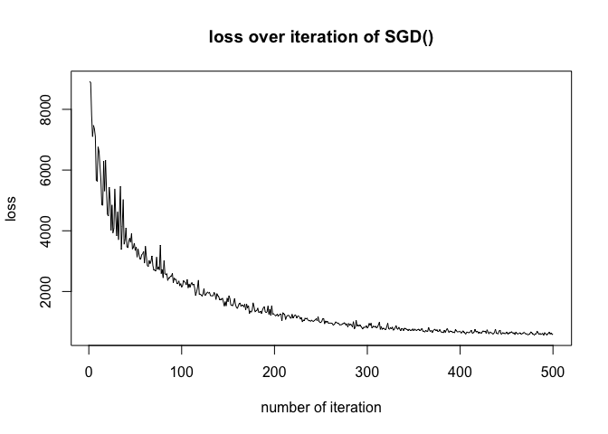

```r
################################################################
#loss function for my package
loss <- function(w, X, y, alpha, lambda){
  # X should contain the intercept column
  w <- matrix(w) # get coef
  sum((X%*%w - y)^2)/2 + lambda*alpha*sum(abs(w))
}
################################################################
# test
loss_my <- rep(0,500)

for (iter in 1:500){
  my_lasso <- SGD(X,y, iter, 0.001, 1, 0.005)
  loss_my[iter] <- loss(my_lasso, X, y, 1, 0.001)
}

plot(loss_my, type="l", main="loss over iteration of SGD()", xlab="number of iteration", ylab="loss")
```